# MultiNicheNet analysis: MIS-C threewise comparison - step-by-step

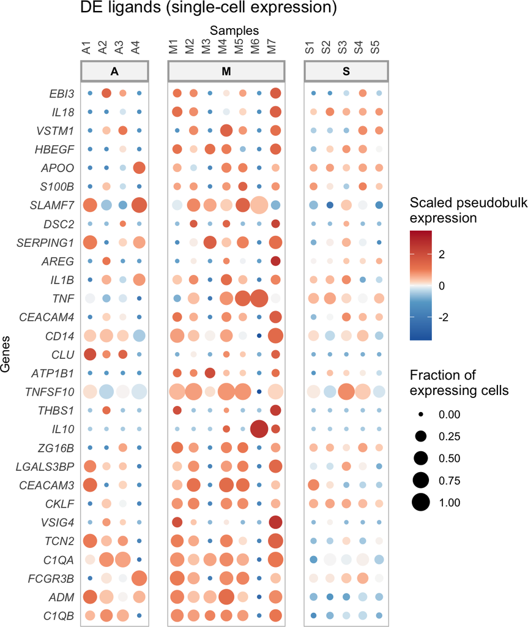

```r
p_target$singlecell_plot + ggtitle("DE ligands (single-cell expression)")
```

Receptors:

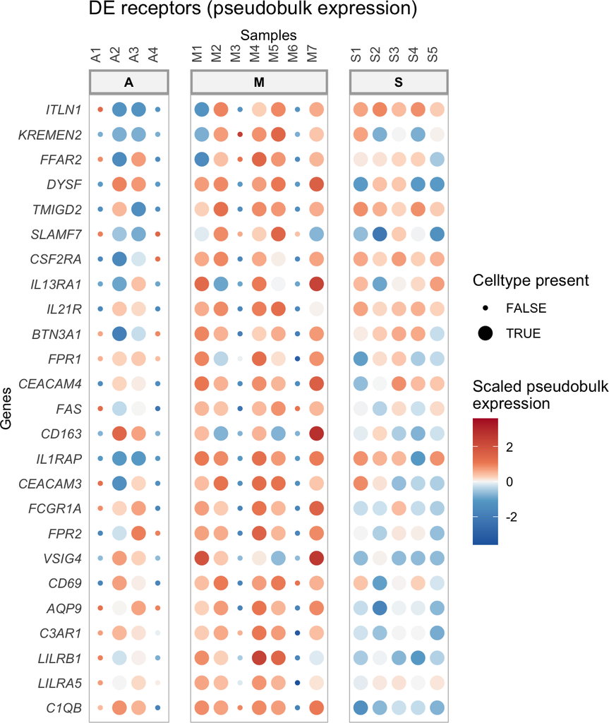

```r
group_oi = "M"
receiver_oi = "M_Monocyte_CD16"
DE_genes = multinichenet_output$ligand_activities_targets_DEgenes$de_genes_df %>%
  inner_join(contrast_tbl) %>%
  filter(group == group_oi) %>%
  arrange(p_val) %>%
  filter(
    receiver == receiver_oi &
      logFC > 1 &
      p_val <= 0.05 &
      contrast == contrast_tbl %>% filter(group == group_oi) %>% pull(contrast)) %>%
  pull(gene) %>% unique()
DE_genes = DE_genes %>% intersect(lr_network$receptor)
p_target = make_DEgene_dotplot_pseudobulk(
  genes_oi = DE_genes,
  celltype_info = multinichenet_output$celltype_info,
  prioritization_tables = multinichenet_output$prioritization_tables,
  celltype_oi = receiver_oi,
  multinichenet_output$grouping_tbl)
p_target$pseudobulk_plot + ggtitle("DE receptors (pseudobulk expression)")
```

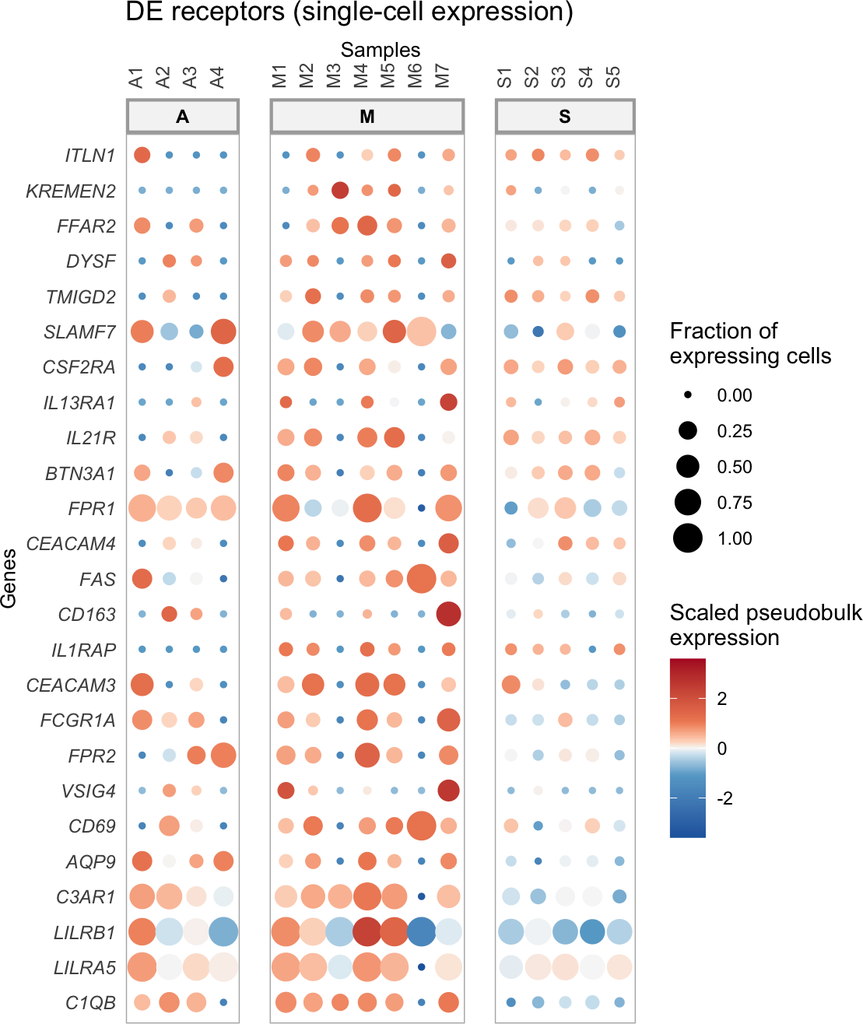

```r
p_target$singlecell_plot + ggtitle("DE receptors (single-cell expression)")
```

# 4 Conclusion

This vignette covered all the details of a MultiNicheNet analysis, from running the algorithm to interpreting its output till the finest details. It’s important to realize that interpreting the output requires quite some time and different levels of iterations: start with the big picture and focus on the most differential LR pairs first. Then later, zoom in on target genes and perform the necessary “sound checks” when going further.